# DATA-413/613 HW 1

2021-08-26

# Instructions

Complete both the Admin elements and the Analysis Elements of this assignment.

## Admin elements:

1. Upload a photo (headshot) of yourself into your canvas profile
2. Review the Syllabus and the [academic integrity code](https://www.american.edu/policies/students/upload/academic-integrity-code-2020.pdf).
3. If not already complete, fill in your information in the Student Info spreadsheet under the Canvas Collaboration site.

## Analysis Elements:

Rename the starter file under the analysis directory as `hw01_yourname.Rmd` and use it for your solutions.  
1. Modify the “author” field in the YAML header.  
2. Stage and commit R Markdown and HTML files (no PDF files).  
3. **Push both .Rmd and HTML files to GitHub**.  
- Make sure you have knitted to HTML prior to staging, committing, and pushing your final submission.  
4. **Commit each time you answer a part of question, e.g. 1.1**  
5. **Push to GitHub after each major question**, e.g., College Scorecard and World Bank Data  
- **Committing and Pushing are graded elements for this homework.**  
6. When complete, submit a response in Canvas that you have completed the homework. No need to submit your files.

- Only include necessary code to answer the questions.
- Most of the functions you use should be from the tidyverse. Too much base R will result in point deductions.
- Use pull requests and or email to ask me any questions. If you email, ensure your most recent code is pushed to GitHub whether it is working or not.

# Learning Outcomes:

- Operate with Git and GitHub.
- Apply concepts and methods from DATA-412/612.

# Grading Criteria

| Question.Part: | Points | Topic |
| --- | --- | --- |
| 1.1 | .50 | Photo |
| 1.2 | 1.00 | Syllabus Review |
| 1.3 | 1.00 | Academic Integrity Review and Commitment |
| 1.4 | .50 | Student Info Completed |
| 2.1 | 1.00 | Load data using a readr function and a relative pathand Fix NULL |
| 2.2 | .50 | Identify character data that should be numeric and the reason why it’s character |
| 2.3 | 1.00 | Use readr function to adjust data to numeric |
| 2.4a | 1.00 | Appropriate plot with linear smoother for Faculty Salary |
| 2.4b | .50 | Reduced overplotting |
| 2.4c | .50 | Interpretation of Faculty Salary and Median Earnings |
| 2.5a | 1.50 | Reproduce Level of Institution plot with data and all labels |
| 2.5b | 1.00 | Interpretation of Level of Institution and Median Earnings |
| 2.6a | 1.00 | Plot for WHITE and Earnings |
| 2.6b | .50 | Description and Interpretation |
| 2.6c | 1.00 | Plot for FEMALE and Earnings |
| 2.6d | .50 | Description and Interpretation |
| 2.7a | 1.00 | Plot data for Mean vs Median with abline and color coding |
| 2.7b | .50 | Interpretation |
| 2.8a | 2.00 | Correct Rank Calculations |
| 2.8b | 1.00 | Top and Bottom 5 |
| 2.8c | .50 | Correct AU Rank |
| 2.8 EC 1 | 1.00 | Correct plot with all labels and lines |
| 2.8 EC 2 | .50 | New ranking and ROI |
| 2.0 | 4.00 | At least 8 Commits and one Push |
| 3.1 | .50 | Load Data using a readr function and relative path |
| 3.2 | 1.00 | Tidy Data has correct data type |
| 3.3 | 1.00 | Combine Data Frames using dplyr and save to new data frame |
| 3.4a | .50 | Plot Data for Fertility vs life expectancy |
| 3.4b | .50 | Plot AES, geoms, and Facet |
| 3.4c | 1.00 | Plot Labels, Scales and Colors |
| 3.4d | .50 | Plot Interpretation |
| 3.5a | 1.50 | Plot Data for total population |
| 3.5b | .50 | Plot AES and geoms |
| 3.5c | 1.00 | Plot Labels, Scales and Theme |
| 3.6a | .50 | Plot Data Population vs Region |
| 3.6b | .50 | Plot AES and geoms to include proper order of Regions |
| 3.6c | .50 | Plot Labels, Scales and Theme |
| 3.0 | 3.50 | At least 6 Commits and one Push |
| **Total** | **35** | Plus 1.5 possible extra credit |

# 1 Canvas Picture, Syllabus, and Student Info

# 2 College Scorecard

The data folder contains “college_scorecard_extract_ 2021-01-19.csv”, a subset of the data in the [College Scorecard](https://collegescorecard.ed.gov/data/) database as of January 19, 2021. These data contain information on colleges in the United States. The variables include:

- `UNITID` and `OPEID`: Identifiers for the colleges.
- `INSTNM`: Institution name
- `ADM_RATE`: The Admission Rate.
- `SAT_AVE`: Average SAT equivalent score of students admitted.
- `UGDS`: Enrollment of undergraduate certificate/degree-seeking students
- `COSTT4_A`: Average cost of attendance (academic year institutions)
- `AVGFACSAL`: Average faculty salary
- `GRAD_DEBT_MDN`: The median debt for students who have completed
- `AGE_ENTRY`: Average age of entry
- `ICLEVEL`: Level of institution (1 = 4-year, 2 = 2-year, 3 = less than 2-year).
- `MN_EARN_WNE_P10`: Mean earnings of students working and not enrolled 10 years after entry.
- `MD_EARN_WNE_P10`: Median earnings of students working and not enrolled 10 years after entry.
- `FEMALE`: Share of female students
- `PCT_WHITE`: Percent of the population from students’ zip codes that is White, via Census data
1. Use a relative path and a readr function to load the data from data/college_score_200601.csv into a tibble. Note, this data uses NULL instead of `NA` so convert NULL to `NA` while reading in.
2. If you used the default settings for reading in the data, multiple variables are probably type character when they should be numeric.
- Which ones?
- Why were they read in as type character?
3. Use a readr function to fix these variables to be numeric and save the updated tibble.
4. How is average faculty salary associated with the median earnings of students ten years after initial enrollment?
- Choose response and explanatory variables based on a reasonable hypothesis.
- Create an appropriate plot to assess for a linear relationship with smoother
- Use a ggplot2 function to try to reduce overplotting.
- Interpret the plot to justify your answer.
5. Does the level of the institution seem to be associated with the median earnings of students ten years after enrollment?
- Reproduce this plot in R to explore this relationship
- Interpret the plot

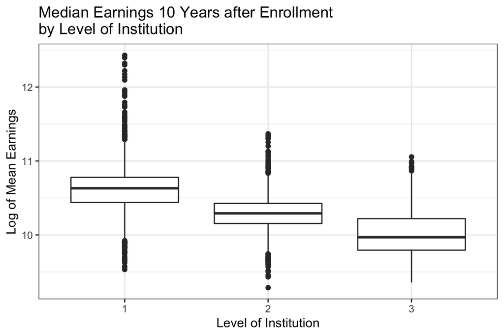

6. Plot the median earnings 10 years after enrollment for level 1 institutions as the Y axis against PCT_WHITE and, in a second plot, against FEMALE.
- Use a log scale as appropriate.
- Add a loess smoother.
- Describe and interpret the non-linear relationship in each of the plots.
7. Create a scatter plot of the mean earnings 10 years after enrollment (Y) axis) compared to the median earnings 10 years after enrollment (X axis) using log scales for both.
- Add an abline.
- Use color to differentiate the level of institutions and attempt to reduce effects of overplotting.
- Interpret the plot and the relationship between the two variables.
8. Compute a ranking of level 1 universities based on the ratio of median earnings 10 years after enrollment compared to median graduation debt.
- Identify the top 5 best (highest ROI should be #1 ) and the bottom 5 worst
- What is American University’s rank and ROI?
- Extra Credit:
  - Reproduce the following plot so the *AU line and number of institutions automatically adjusts as new data is entered*:
  - What is AU’s new ranking and ROI if the mean earnings are used?

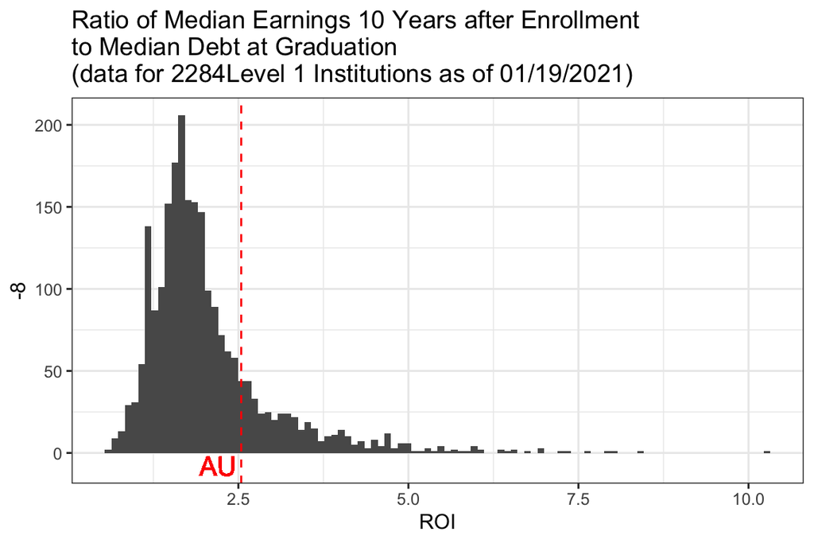

# 3 World Bank Data

The World Bank provides loans to countries with the goal of reducing poverty. The dataframes in the data folder were taken from the public data repositories of the World Bank.

- `country.csv`: Contains information on the countries in the data set. The variables are:
  - `Country_Code`: A three-letter code for the country. Note not all rows are countries; some are regions.
  - `Region`: The region of the country.
  - `IncomeGroup`: Either `"High income"`, `"Upper middle income"`, `"Lower middle income"`, or `"Low income"`.
  - `TableName`: The full name of the country.
- `fertility.csv`: Contains the fertility rate information for each country for each year.
  - For the variables `1960` to `2017`, the values in the cells represent the fertility rate in total births per woman for that year.
  - Total fertility rate represents the number of children that would be born to a woman if she were to live to the end of her childbearing years and bear children in accordance with age-specific fertility rates of the specified year.
- `life_exp.csv`: Contains the life expectancy information for each country for each year.
  - For the variables `1960` to `2017`, the values in the cells represent life expectancy at birth in years for the given year.
  - Life expectancy at birth indicates the number of years a newborn infant would live if prevailing patterns of mortality at the time of its birth were to stay the same throughout its life.
- `population.csv`: Contains the population information for each country.
  - For the variables `1960` to `2017`, the values in the cells represent the total population in number of people for the given year.
  - Total population is based on the de facto definition of population, which counts all residents regardless of legal status or citizenship. The values shown are mid-year estimates.
1. Use relative paths and a readr function to load these files into four tibbles.
2. These data are messy. The observational units in `fert`, `life`, and `pop` are locations in space-time (e.g. Aruba in 2017). Recall tidy data should have one observational unit per row.
- Use tidyr functions to tidy these three tibbles and save the updated data frames.
- Use an argument so the readr function ensures the variable for `year` is a numeric.
3. Use dplyr functions to combine the three tibbles into one and save to a new tibble which includes the fertility rate, population, and life expectancy in each year as well as the region for each country.
4. Make a scatterplot of fertility rate vs life expectancy, color-coding by region and annotating size by the population.
- Include only the years 1960, 1970, 1980, 1990, 2000, and 2010.
- Facet by these years.
- Your final plot should look like this (Each element of the formatting is graded):
- **Interpret the plot in one sentence**.

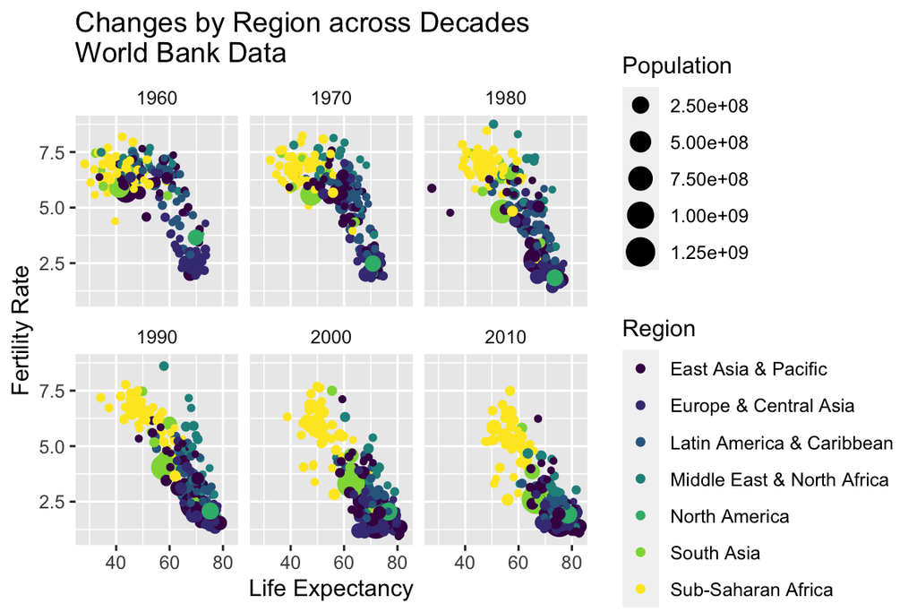

5. Calculate the total population for each region for each year.
- Exclude 2018.
- Make a line plot of year versus total population, color-coding by region and using a log scale.
- Your final plot should look like this:
- **Interpret the plot in one sentence to identify the two fastest growing regions**.

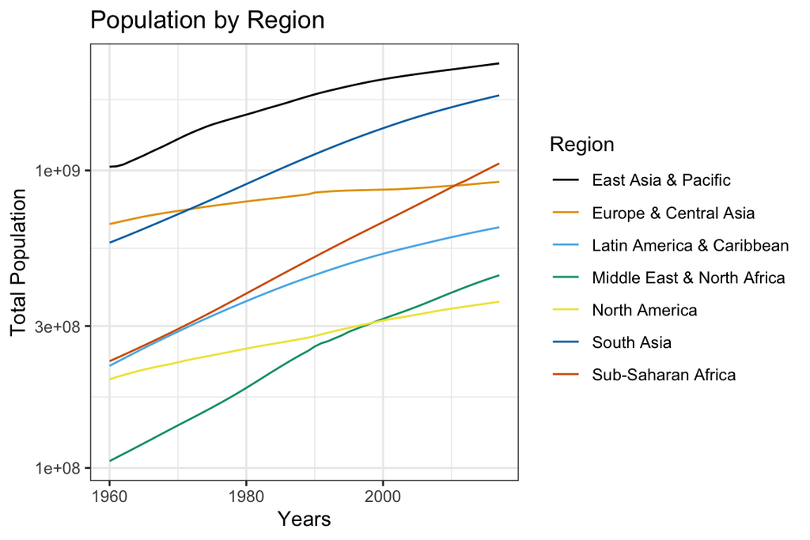

6. Make a bar plot of population vs region for the year 2010.
- Order the bars on the $y$-axis in **increasing** order of population.
- Your final plot should look like this:

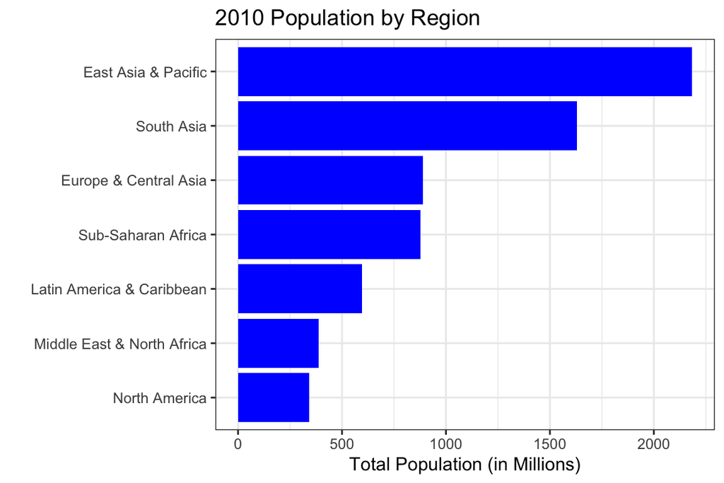